# Program Summary - Max_Midterm_Software.sas

### Results: Max_Midterm_Software.sas

The CONTENTS Procedure

| Data Set Name | MIDTERM.FORMATTED | Observations | 641934 |
| --- | --- | --- | --- |
| Member Type | DATA | Variables | 42 |
| Engine | V9 | Indexes | 0 |
| Created | 11/16/2025 20:47:12 | Observation Length | 248 |
| Last Modified | 11/16/2025 20:47:12 | Deleted Observations | 0 |
| Protection |  | Compressed | NO |
| Data Set Type |  | Sorted | NO |
| Label |  |  |  |
| Data Representation | SOLARIS_X86_64, LINUX_X86_64, ALPHA_TRU64, LINUX_IA64 |  |  |
| Encoding | utf-8 Unicode (UTF-8) |  |  |

[output not shown]

| Alphabetic List of Variables and Attributes # | Alphabetic List of Variables and Attributes Variable | Alphabetic List of Variables and Attributes Type | Alphabetic List of Variables and Attributes Len | Alphabetic List of Variables and Attributes Format | Alphabetic List of Variables and Attributes Label |
| --- | --- | --- | --- | --- | --- |
| 7 | AGER5 | Num | 8 | AGER5F. | Infant age at death recode |
| 12 | APGAR5 | Num | 8 | 2. | 5-minute APGAR score (test of general condition) |
| 1 | BIRTHID | Num | 8 | BIRTHIDF. | Record category: Survivor / Infant death / Fetal death |
| 28 | BMI_R | Num | 8 | BMI_RF. | Body Mass Index (Assumed Maternal & recode) |
| 9 | BWTR4 | Num | 8 | BW4F. | Newborn Birthweight (4 categories) |
| 8 | BWTR12 | Num | 8 | BW12F. | Newborn Birthweight (12 categories) |
| 25 | CIG0_R | Num | 8 | CIG0RF. | Cigarettes before pregnancy (recode) |
| 21 | CIG_0 | Num | 8 | 3. | Cigarettes/day, 3 months before pregnancy |
| 22 | CIG_1 | Num | 8 | 3. | Cigarettes/day, 1st trimester |
| 23 | CIG_2 | Num | 8 | 3. | Cigarettes/day, 2nd trimester |
| 24 | CIG_3 | Num | 8 | 3. | Cigarettes/day, 3rd trimester |
| 26 | CIG_R | Char | 1 | $YESNOF. | Smoked during pregnancy (Y/N/U) |
| 3 | COUNT | Num | 8 | CNTF. | Number of matched records in set |
| 15 | DMETHOD | Num | 8 | DMETHF. | Delivery method |
| 29 | FAGER11 | Num | 8 | FAGERF. | Paternal age group |
| 30 | FEDUC | Num | 8 | FEDUCF. | Paternal education |
| 19 | ILP_R11 | Num | 8 | ILP11F. | Interval since last pregnancy recode |
| 39 | IP_CHLAM | Char | 1 | $YESNOF. | Chlamydia (Y/N/U) |
| 37 | IP_GON | Char | 1 | $YESNOF. | Gonorrhea (Y/N/U) |
| 40 | IP_HEPB | Char | 1 | $YESNOF. | Hepatitis B (Y/N/U) |
| 41 | IP_HEPC | Char | 1 | $YESNOF. | Hepatitis C (Y/N/U) |
| 38 | IP_SYPH | Char | 1 | $YESNOF. | Syphilis (Y/N/U) |
| 17 | MAGER9 | Num | 8 | MAGER9F. | Maternal age group |
| 10 | MANNER | Num | 8 | MANNERF. | Manner of death |
| 18 | MEDUC | Num | 8 | MEDUCF. | Maternal education |
| 13 | ME_PRES | Num | 8 | PRESF. | Fetal presentation at delivery |
| 14 | ME_ROUT | Num | 8 | ROUTF. | Route & method of delivery |
| 4 | MULTID | Num | 8 | Z6. | Matched set ID |
| 20 | NATIVITY | Num | 8 | NATIVF. | Maternal nativity (born in/outside US) |
| 6 | NO_ABNORM | Num | 8 | NOABF. | No abnormal conditions checked |
| 42 | NO_INFEC | Num | 8 | NOINFECF. | No infections reported |
| 16 | NO_MMORB | Num | 8 | NOMORB. | No maternal morbidity reported |
| 32 | NO_RISKS | Num | 8 | NORISKF. | No risk factors reported (based on maternal characteristics) |
| 11 | OEGEST_R12 | Num | 8 | OEG12F. | Gestational age recode (12 categories) |
| 2 | PLURAL | Num | 8 | PLURF. | Birth type (twin/triplet/quadruplet) |
| 31 | RF_CESAR | Char | 1 | $YESNOF. | Previous cesarean (Y/N/U) |
| 34 | RF_GDIAB | Char | 1 | $YESNOF. | Gestational diabetes (Y/N/U) |
| 36 | RF_GHYPE | Char | 1 | $YESNOF. | Gestational hypertension (Y/N/U) |
| 27 | RF_INFTR | Char | 1 | $YESNOF. | Infertility treatment used (Y/N/U) |
| 33 | RF_PDIAB | Char | 1 | $YESNOF. | Prepregnancy diabetes (Y/N/U) |
| 35 | RF_PHYPE | Char | 1 | $YESNOF. | Prepregnancy hypertension (Y/N/U) |
| 5 | SEX | Char | 1 | $SEXF. | Infant sex |

Twin Outcomes

| OutcomeLabel | Number |
| --- | --- |
| 1 infant death + 1 fetal death | 353 |
| 1 survivor + 1 fetal death | 2990 |
| 1 survivor + 1 infant death | 5611 |
| 2 fetal deaths | 1684 |
| 2 infant deaths | 118 |
| 2 survivors | 298225 |
| Total sets of twins | 314972 |

Triplet Outcomes

| OutcomeLabel | Number |
| --- | --- |
| 1 infant death + 2 fetal deaths | 9 |
| 1 survivor + 1 infant death + 1 fetal death | 34 |
| 1 survivor + 2 fetal deaths | 53 |
| 1 survivor + 2 infant deaths | 65 |
| 2 survivors + 1 fetal death | 110 |
| 2 survivors + 1 infant death | 251 |
| 3 fetal deaths | 36 |
| 3 infant deaths | 1 |
| 3 survivors | 4970 |
| Total sets of triplets | 5958 |

Quadruplet Outcomes

| OutcomeLabel | Number |
| --- | --- |
| 1 survivor + 2 infant + 1 fetal death | 1 |
| 1 survivor + 3 fetal deaths | 2 |
| 2 survivors + 1 infant + 1 fetal death | 2 |
| 2 survivors + 2 fetal deaths | 4 |
| 2 survivors + 2 infant deaths | 7 |
| 3 survivors + 1 fetal death | 5 |
| 3 survivors + 1 infant death | 10 |
| 4 fetal deaths | 2 |
| 4 survivors | 143 |
| Total sets of quadruplets | 222 |

The FREQ Procedure

| Frequency Percent Row Pct Col Pct |
| --- |

| Table of PLURAL by outcome_simplified PLURAL(Birth type (twin/triplet/quadruplet)) | Table of PLURAL by outcome_simplified outcome_simplified 2 survivors | Table of PLURAL by outcome_simplified outcome_simplified 3 survivors | Table of PLURAL by outcome_simplified outcome_simplified 4 survivors | Table of PLURAL by outcome_simplified outcome_simplified Other quadruplet outcome | Table of PLURAL by outcome_simplified outcome_simplified Other triplet outcome | Table of PLURAL by outcome_simplified outcome_simplified Other twin outcome | Table of PLURAL by outcome_simplified outcome_simplified Total |
| --- | --- | --- | --- | --- | --- | --- | --- |
| Twin | 596450 92.91 95.59 100.00 | 0 0.00 0.00 0.00 | 0 0.00 0.00 0.00 | 0 0.00 0.00 0.00 | 0 0.00 0.00 0.00 | 27503 4.28 4.41 100.00 | 623953 97.20 |
| Triplet | 0 0.00 0.00 0.00 | 14910 2.32 86.69 100.00 | 0 0.00 0.00 0.00 | 0 0.00 0.00 0.00 | 2289 0.36 13.31 100.00 | 0 0.00 0.00 0.00 | 17199 2.68 |
| Quadruplet | 0 0.00 0.00 0.00 | 0 0.00 0.00 0.00 | 572 0.09 73.15 100.00 | 210 0.03 26.85 100.00 | 0 0.00 0.00 0.00 | 0 0.00 0.00 0.00 | 782 0.12 |
| Total | 596450 92.91 | 14910 2.32 | 572 0.09 | 210 0.03 | 2289 0.36 | 27503 4.28 | 641934 100.00 |

The FREQ Procedure

| Delivery method DMETHOD | Delivery method Frequency | Delivery method Percent |
| --- | --- | --- |
| Vaginal (non-C-section) | 167201 | 26.05 |
| Vaginal after C-section | 5419 | 0.84 |
| Primary C-section | 361532 | 56.32 |
| Repeat C-section | 106563 | 16.60 |
| Vaginal (prev C-section unknown) | 384 | 0.06 |
| C-section (prev C-section unknown) | 299 | 0.05 |
| Unknown | 536 | 0.08 |

The FREQ Procedure

| Maternal education MEDUC | Maternal education Frequency | Maternal education Percent |
| --- | --- | --- |
| ≤8th grade | 13440 | 2.09 |
| 9–12 no diploma | 46246 | 7.20 |
| High school/GED | 142876 | 22.26 |
| Some college | 123721 | 19.27 |
| Associate degree | 56018 | 8.73 |
| Bachelor’s | 148131 | 23.08 |
| Master’s | 76661 | 11.94 |
| Doctorate/Professional | 22500 | 3.51 |
| Unknown | 12341 | 1.92 |

Event Distribution – Twins

The FREQ Procedure

| outcome_flag | Frequency | Percent |
| --- | --- | --- |
| 0 | 27503 | 4.41 |
| 1 | 596450 | 95.59 |

Event Distribution – Twins

The LOGISTIC Procedure

| Model Information |  |
| --- | --- |
| Data Set | WORK.TWINS |
| Response Variable | outcome_flag |
| Number of Response Levels | 2 |
| Model | binary logit |
| Optimization Technique | Fisher's scoring |

| Number of Observations Read | 623953 |
| --- | --- |
| Number of Observations Used | 599175 |

| Response Profile Ordered Value | Response Profile outcome_flag | Response Profile Total Frequency |
| --- | --- | --- |
| 1 | 0 | 18651 |
| 2 | 1 | 580524 |

Probability modeled is outcome_flag=1.

Note:24778 observations were deleted due to missing values for the response or explanatory variables.

| Class Level Information Class | Class Level Information Value | Class Level Information Design Variables | Class Level Information Design Variables | Class Level Information Design Variables | Class Level Information Design Variables | Class Level Information Design Variables | Class Level Information Design Variables | Class Level Information Design Variables |
| --- | --- | --- | --- | --- | --- | --- | --- | --- |
| MEDUC | 9–12 no diploma | 0 | 0 | 0 | 0 | 0 | 0 | 0 |
|  | Associate degree | 1 | 0 | 0 | 0 | 0 | 0 | 0 |
|  | Bachelor’s | 0 | 1 | 0 | 0 | 0 | 0 | 0 |
|  | Doctorate/Professional | 0 | 0 | 1 | 0 | 0 | 0 | 0 |
|  | High school/GED | 0 | 0 | 0 | 1 | 0 | 0 | 0 |
|  | Master’s | 0 | 0 | 0 | 0 | 1 | 0 | 0 |
|  | Some college | 0 | 0 | 0 | 0 | 0 | 1 | 0 |
|  | ≤8th grade | 0 | 0 | 0 | 0 | 0 | 0 | 1 |
| NATIVITY | Born in US | 0 |  |  |  |  |  |  |
|  | Born outside US | 1 |  |  |  |  |  |  |
| DMETHOD | C-section (prev C-section unknown) | 0 | 0 | 0 | 0 | 0 |  |  |
|  | Primary C-section | 1 | 0 | 0 | 0 | 0 |  |  |
|  | Repeat C-section | 0 | 1 | 0 | 0 | 0 |  |  |
|  | Vaginal (non-C-section) | 0 | 0 | 1 | 0 | 0 |  |  |
|  | Vaginal (prev C-section unknown) | 0 | 0 | 0 | 1 | 0 |  |  |
|  | Vaginal after C-section | 0 | 0 | 0 | 0 | 1 |  |  |

| Model Convergence Status |
| --- |
| Convergence criterion (GCONV=1E-8) satisfied. |

| Model Fit Statistics Criterion | Model Fit Statistics Intercept Only | Model Fit Statistics Intercept and Covariates |
| --- | --- | --- |
| AIC | 166142.35 | 160171.76 |
| SC | 166153.65 | 160363.91 |
| -2 Log L | 166140.35 | 160137.76 |

| R-Square | 0.0100 | Max-rescaled R-Square | 0.0412 |
| --- | --- | --- | --- |

| Testing Global Null Hypothesis: BETA=0 Test | Testing Global Null Hypothesis: BETA=0 Chi-Square | Testing Global Null Hypothesis: BETA=0 DF | Testing Global Null Hypothesis: BETA=0 Pr > ChiSq |
| --- | --- | --- | --- |
| Likelihood Ratio | 6002.5902 | 16 | <.0001 |
| Score | 6639.6403 | 16 | <.0001 |
| Wald | 6194.0123 | 16 | <.0001 |

| Type 3 Analysis of Effects Effect | Type 3 Analysis of Effects DF | Type 3 Analysis of Effects Wald Chi-Square | Type 3 Analysis of Effects Pr > ChiSq |
| --- | --- | --- | --- |
| MEDUC | 7 | 725.4426 | <.0001 |
| NATIVITY | 1 | 2.2920 | 0.1300 |
| CIG_Rn | 1 | 23.8025 | <.0001 |
| NO_INFEC | 1 | 0.3250 | 0.5686 |
| NO_ABNORM | 1 | 1359.7499 | <.0001 |
| DMETHOD | 5 | 4284.2885 | <.0001 |

| Analysis of Maximum Likelihood Estimates Parameter | Analysis of Maximum Likelihood Estimates | Analysis of Maximum Likelihood Estimates DF | Analysis of Maximum Likelihood Estimates Estimate | Analysis of Maximum Likelihood Estimates Standard Error | Analysis of Maximum Likelihood Estimates Wald Chi-Square | Analysis of Maximum Likelihood Estimates Pr > ChiSq | Analysis of Maximum Likelihood Estimates Standardized Estimate |
| --- | --- | --- | --- | --- | --- | --- | --- |
| Intercept |  | 1 | 2.1031 | 0.3724 | 31.9004 | <.0001 |  |
| MEDUC | Associate degree | 1 | 0.2171 | 0.0360 | 36.4779 | <.0001 | 0.0341 |
| MEDUC | Bachelor’s | 1 | 0.4190 | 0.0309 | 183.6136 | <.0001 | 0.0979 |
| MEDUC | Doctorate/Professional | 1 | 0.6152 | 0.0552 | 124.0270 | <.0001 | 0.0631 |
| MEDUC | High school/GED | 1 | -0.0540 | 0.0285 | 3.5828 | 0.0584 | -0.0125 |
| MEDUC | Master’s | 1 | 0.4756 | 0.0357 | 177.1772 | <.0001 | 0.0858 |
| MEDUC | Some college | 1 | 0.1336 | 0.0300 | 19.8026 | <.0001 | 0.0293 |
| MEDUC | ≤8th grade | 1 | -0.00270 | 0.0534 | 0.0026 | 0.9596 | -0.00021 |
| NATIVITY | Born outside US | 1 | 0.0310 | 0.0204 | 2.2920 | 0.1300 | 0.00671 |
| CIG_Rn |  | 1 | -0.1368 | 0.0280 | 23.8025 | <.0001 | -0.0182 |
| NO_INFEC |  | 1 | 0.0248 | 0.0435 | 0.3250 | 0.5686 | 0.00212 |
| NO_ABNORM |  | 1 | 0.5586 | 0.0151 | 1359.7499 | <.0001 | 0.1519 |
| DMETHOD | Primary C-section | 1 | 1.1648 | 0.3696 | 9.9316 | 0.0016 | 0.3185 |
| DMETHOD | Repeat C-section | 1 | 1.2170 | 0.3701 | 10.8141 | 0.0010 | 0.2503 |
| DMETHOD | Vaginal (non-C-section) | 1 | 0.2598 | 0.3696 | 0.4940 | 0.4822 | 0.0629 |
| DMETHOD | Vaginal (prev C-section unknown) | 1 | -0.8044 | 0.5192 | 2.3999 | 0.1213 | -0.00444 |
| DMETHOD | Vaginal after C-section | 1 | -0.5052 | 0.3724 | 1.8406 | 0.1749 | -0.0248 |

| Odds Ratio Estimates and Wald Confidence Intervals Effect | Odds Ratio Estimates and Wald Confidence Intervals Unit | Odds Ratio Estimates and Wald Confidence Intervals Estimate | Odds Ratio Estimates and Wald Confidence Intervals 95% Confidence Limits | Odds Ratio Estimates and Wald Confidence Intervals 95% Confidence Limits |
| --- | --- | --- | --- | --- |
| MEDUC Associate degree vs 9–12 no diploma | 1.0000 | 1.243 | 1.158 | 1.333 |
| MEDUC Bachelor’s vs 9–12 no diploma | 1.0000 | 1.520 | 1.431 | 1.615 |
| MEDUC Doctorate/Professional vs 9–12 no diploma | 1.0000 | 1.850 | 1.660 | 2.061 |
| MEDUC High school/GED vs 9–12 no diploma | 1.0000 | 0.947 | 0.896 | 1.002 |
| MEDUC Master’s vs 9–12 no diploma | 1.0000 | 1.609 | 1.500 | 1.726 |
| MEDUC Some college vs 9–12 no diploma | 1.0000 | 1.143 | 1.078 | 1.212 |
| MEDUC ≤8th grade vs 9–12 no diploma | 1.0000 | 0.997 | 0.898 | 1.107 |
| NATIVITY Born outside US vs Born in US | 1.0000 | 1.031 | 0.991 | 1.074 |
| CIG_Rn | 1.0000 | 0.872 | 0.826 | 0.921 |
| NO_INFEC | 1.0000 | 1.025 | 0.941 | 1.116 |
| NO_ABNORM | 1.0000 | 1.748 | 1.697 | 1.801 |
| DMETHOD Primary C-section vs C-section (prev C-section unknown) | 1.0000 | 3.205 | 1.553 | 6.614 |
| DMETHOD Repeat C-section vs C-section (prev C-section unknown) | 1.0000 | 3.377 | 1.635 | 6.975 |
| DMETHOD Vaginal (non-C-section) vs C-section (prev C-section unknown) | 1.0000 | 1.297 | 0.628 | 2.676 |
| DMETHOD Vaginal (prev C-section unknown) vs C-section (prev C-section unknown) | 1.0000 | 0.447 | 0.162 | 1.238 |
| DMETHOD Vaginal after C-section vs C-section (prev C-section unknown) | 1.0000 | 0.603 | 0.291 | 1.252 |

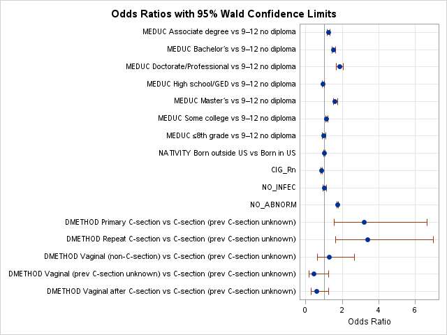

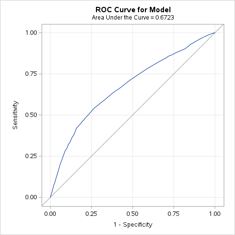

| Partition for the Hosmer and Lemeshow Test Group | Partition for the Hosmer and Lemeshow Test Total | Partition for the Hosmer and Lemeshow Test outcome_flag = 1 Observed | Partition for the Hosmer and Lemeshow Test outcome_flag = 1 Expected | Partition for the Hosmer and Lemeshow Test outcome_flag = 0 Observed | Partition for the Hosmer and Lemeshow Test outcome_flag = 0 Expected |
| --- | --- | --- | --- | --- | --- |
| 1 | 60013 | 56615 | 55502.24 | 3398 | 4510.76 |
| 2 | 60084 | 56540 | 57223.64 | 3544 | 2860.36 |
| 3 | 59214 | 56429 | 56992.78 | 2785 | 2221.22 |
| 4 | 71464 | 68641 | 69137.07 | 2823 | 2326.93 |
| 5 | 67226 | 65018 | 65437.30 | 2208 | 1788.70 |
| 6 | 59794 | 58536 | 58453.11 | 1258 | 1340.89 |
| 7 | 56879 | 55905 | 55708.25 | 974 | 1170.75 |
| 8 | 58211 | 57559 | 57185.80 | 652 | 1025.20 |
| 9 | 62397 | 61781 | 61536.59 | 616 | 860.41 |
| 10 | 43893 | 43500 | 43346.96 | 393 | 546.04 |

| Hosmer and Lemeshow Goodness-of-Fit Test Chi-Square | Hosmer and Lemeshow Goodness-of-Fit Test DF | Hosmer and Lemeshow Goodness-of-Fit Test Pr > ChiSq |
| --- | --- | --- |
| 1118.4681 | 8 | <.0001 |

ROC Model: Twins Model

| Model Convergence Status |
| --- |
| Convergence criterion (GCONV=1E-8) satisfied. |

| -2 Log L | = | 166140.35 |
| --- | --- | --- |

| Analysis of Maximum Likelihood Estimates Parameter | Analysis of Maximum Likelihood Estimates DF | Analysis of Maximum Likelihood Estimates Estimate | Analysis of Maximum Likelihood Estimates Standard Error | Analysis of Maximum Likelihood Estimates Wald Chi-Square | Analysis of Maximum Likelihood Estimates Pr > ChiSq | Analysis of Maximum Likelihood Estimates Standardized Estimate |
| --- | --- | --- | --- | --- | --- | --- |
| Intercept | 1 | 3.4380 | 0.00744 | 213593.626 | <.0001 |  |

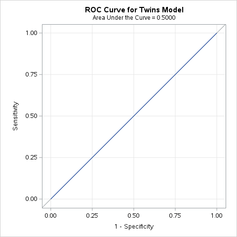

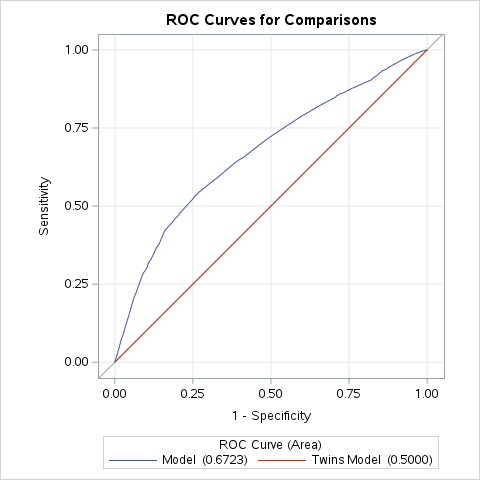

| ROC Association Statistics ROC Model | ROC Association Statistics Mann-Whitney Area | ROC Association Statistics Mann-Whitney Standard Error | ROC Association Statistics Mann-Whitney 95% Wald Confidence Limits | ROC Association Statistics Mann-Whitney 95% Wald Confidence Limits | ROC Association Statistics Somers' D | ROC Association Statistics Gamma | ROC Association Statistics Tau-a |  |  |  |
| --- | --- | --- | --- | --- | --- | --- | --- | --- | --- | --- |
| Model | 0.6723 | 0.00184 | 0.6687 | 0.6760 |  |  |  | 0.3447 | 0.3514 | 0.0208 |
| Twins Model | 0.5000 | 0 | 0.5000 | 0.5000 | 0 | . | 0 |  |  |  |

The CONTENTS Procedure

| Data Set Name | WORK.ODDSRATIOWALDS_TWINS | Observations | 16 |
| --- | --- | --- | --- |
| Member Type | DATA | Variables | 5 |
| Engine | V9 | Indexes | 0 |
| Created | 11/16/2025 20:47:19 | Observation Length | 120 |
| Last Modified | 11/16/2025 20:47:19 | Deleted Observations | 0 |
| Protection |  | Compressed | NO |
| Data Set Type |  | Sorted | NO |
| Label | 95% Clodds=Wald |  |  |
| Data Representation | SOLARIS_X86_64, LINUX_X86_64, ALPHA_TRU64, LINUX_IA64 |  |  |
| Encoding | utf-8 Unicode (UTF-8) |  |  |

[output not shown]

| Alphabetic List of Variables and Attributes # | Alphabetic List of Variables and Attributes Variable | Alphabetic List of Variables and Attributes Type | Alphabetic List of Variables and Attributes Len | Alphabetic List of Variables and Attributes Format | Alphabetic List of Variables and Attributes Label |
| --- | --- | --- | --- | --- | --- |
| 1 | Effect | Char | 82 |  |  |
| 4 | LowerCL | Num | 8 | ODDSR8.3 | Wald Lower 95% Confidence Limit for Adjusted Odds Ratio |
| 3 | OddsRatioEst | Num | 8 | ODDSR8.3 | Odds Ratio |
| 2 | Unit | Num | 8 | D8. |  |
| 5 | UpperCL | Num | 8 | ODDSR8.3 | Wald Upper 95% Confidence Limit for Adjusted Odds Ratio |

Logistic Regression Parameter Estimates – Twins Model

| Variable | Level of Variable | Estimate | Standard Error | Wald Chi-Square | Pr > Chi-Square | Standardized Estimate (MLE) |
| --- | --- | --- | --- | --- | --- | --- |
| Intercept |  | 2.1031 | 0.3724 | 31.9004 | <.0001 | _ |
| MEDUC | Associate degree | 0.2171 | 0.0360 | 36.4779 | <.0001 | 0.0341 |
| MEDUC | Bachelor’s | 0.4190 | 0.0309 | 183.6136 | <.0001 | 0.0979 |
| MEDUC | Doctorate/Professional | 0.6152 | 0.0552 | 124.0270 | <.0001 | 0.0631 |
| MEDUC | High school/GED | -0.0540 | 0.0285 | 3.5828 | 0.0584 | -0.0125 |
| MEDUC | Master’s | 0.4756 | 0.0357 | 177.1772 | <.0001 | 0.0858 |
| MEDUC | Some college | 0.1336 | 0.0300 | 19.8026 | <.0001 | 0.0293 |
| MEDUC | ≤8th grade | -0.00270 | 0.0534 | 0.0026 | 0.9596 | -0.00021 |
| NATIVITY | Born outside US | 0.0310 | 0.0204 | 2.2920 | 0.1300 | 0.00671 |
| CIG_Rn |  | -0.1368 | 0.0280 | 23.8025 | <.0001 | -0.0182 |
| NO_INFEC |  | 0.0248 | 0.0435 | 0.3250 | 0.5686 | 0.00212 |
| NO_ABNORM |  | 0.5586 | 0.0151 | 1359.7499 | <.0001 | 0.1519 |
| DMETHOD | Primary C-section | 1.1648 | 0.3696 | 9.9316 | 0.0016 | 0.3185 |
| DMETHOD | Repeat C-section | 1.2170 | 0.3701 | 10.8141 | 0.0010 | 0.2503 |
| DMETHOD | Vaginal (non-C-section) | 0.2598 | 0.3696 | 0.4940 | 0.4822 | 0.0629 |
| DMETHOD | Vaginal (prev C-section unknown) | -0.8044 | 0.5192 | 2.3999 | 0.1213 | -0.00444 |
| DMETHOD | Vaginal after C-section | -0.5052 | 0.3724 | 1.8406 | 0.1749 | -0.0248 |
| Intercept |  | 3.4380 | 0.00744 | 213593.626 | <.0001 | _ |

Walds Odd Ratios for Twins

| Effect | Odds Ratio | Wald Lower 95% Confidence Limit for Adjusted Odds Ratio | Wald Upper 95% Confidence Limit for Adjusted Odds Ratio |
| --- | --- | --- | --- |
| MEDUC Associate degree vs 9–12 no diploma | 1.243 | 1.158 | 1.333 |
| MEDUC Bachelor’s vs 9–12 no diploma | 1.520 | 1.431 | 1.615 |
| MEDUC Doctorate/Professional vs 9–12 no diploma | 1.850 | 1.660 | 2.061 |
| MEDUC High school/GED vs 9–12 no diploma | 0.947 | 0.896 | 1.002 |
| MEDUC Master’s vs 9–12 no diploma | 1.609 | 1.500 | 1.726 |
| MEDUC Some college vs 9–12 no diploma | 1.143 | 1.078 | 1.212 |
| MEDUC ≤8th grade vs 9–12 no diploma | 0.997 | 0.898 | 1.107 |
| NATIVITY Born outside US vs Born in US | 1.031 | 0.991 | 1.074 |
| CIG_Rn | 0.872 | 0.826 | 0.921 |
| NO_INFEC | 1.025 | 0.941 | 1.116 |
| NO_ABNORM | 1.748 | 1.697 | 1.801 |
| DMETHOD Primary C-section vs C-section (prev C-section unknown) | 3.205 | 1.553 | 6.614 |
| DMETHOD Repeat C-section vs C-section (prev C-section unknown) | 3.377 | 1.635 | 6.975 |
| DMETHOD Vaginal (non-C-section) vs C-section (prev C-section unknown) | 1.297 | 0.628 | 2.676 |
| DMETHOD Vaginal (prev C-section unknown) vs C-section (prev C-section unknown) | 0.447 | 0.162 | 1.238 |
| DMETHOD Vaginal after C-section vs C-section (prev C-section unknown) | 0.603 | 0.291 | 1.252 |

ROC association stats for Twins

[output not shown]

Event Distribution – Triplets

The FREQ Procedure

| outcome_flag | Frequency | Percent |
| --- | --- | --- |
| 0 | 2289 | 13.31 |
| 1 | 14910 | 86.69 |

Event Distribution – Triplets

The LOGISTIC Procedure

| Model Information |  |
| --- | --- |
| Data Set | WORK.TRIPLETS |
| Response Variable | outcome_flag |
| Number of Response Levels | 2 |
| Model | binary logit |
| Optimization Technique | Fisher's scoring |

| Number of Observations Read | 17199 |
| --- | --- |
| Number of Observations Used | 16215 |

| Response Profile Ordered Value | Response Profile outcome_flag | Response Profile Total Frequency |
| --- | --- | --- |
| 1 | 0 | 1734 |
| 2 | 1 | 14481 |

Probability modeled is outcome_flag=1.

Note:984 observations were deleted due to missing values for the response or explanatory variables.

| Class Level Information Class | Class Level Information Value | Class Level Information Design Variables | Class Level Information Design Variables | Class Level Information Design Variables | Class Level Information Design Variables | Class Level Information Design Variables | Class Level Information Design Variables | Class Level Information Design Variables |
| --- | --- | --- | --- | --- | --- | --- | --- | --- |
| MEDUC | 9–12 no diploma | 0 | 0 | 0 | 0 | 0 | 0 | 0 |
|  | Associate degree | 1 | 0 | 0 | 0 | 0 | 0 | 0 |
|  | Bachelor’s | 0 | 1 | 0 | 0 | 0 | 0 | 0 |
|  | Doctorate/Professional | 0 | 0 | 1 | 0 | 0 | 0 | 0 |
|  | High school/GED | 0 | 0 | 0 | 1 | 0 | 0 | 0 |
|  | Master’s | 0 | 0 | 0 | 0 | 1 | 0 | 0 |
|  | Some college | 0 | 0 | 0 | 0 | 0 | 1 | 0 |
|  | ≤8th grade | 0 | 0 | 0 | 0 | 0 | 0 | 1 |
| NATIVITY | Born in US | 0 |  |  |  |  |  |  |
|  | Born outside US | 1 |  |  |  |  |  |  |
| DMETHOD | C-section (prev C-section unknown) | 0 | 0 | 0 | 0 |  |  |  |
|  | Primary C-section | 1 | 0 | 0 | 0 |  |  |  |
|  | Repeat C-section | 0 | 1 | 0 | 0 |  |  |  |
|  | Vaginal (non-C-section) | 0 | 0 | 1 | 0 |  |  |  |
|  | Vaginal after C-section | 0 | 0 | 0 | 1 |  |  |  |

| Model Convergence Status |
| --- |
| Convergence criterion (GCONV=1E-8) satisfied. |

| Model Fit Statistics Criterion | Model Fit Statistics Intercept Only | Model Fit Statistics Intercept and Covariates |
| --- | --- | --- |
| AIC | 11030.316 | 8936.200 |
| SC | 11038.010 | 9059.299 |
| -2 Log L | 11028.316 | 8904.200 |

| R-Square | 0.1228 | Max-rescaled R-Square | 0.2488 |
| --- | --- | --- | --- |

| Testing Global Null Hypothesis: BETA=0 Test | Testing Global Null Hypothesis: BETA=0 Chi-Square | Testing Global Null Hypothesis: BETA=0 DF | Testing Global Null Hypothesis: BETA=0 Pr > ChiSq |
| --- | --- | --- | --- |
| Likelihood Ratio | 2124.1162 | 15 | <.0001 |
| Score | 3447.6104 | 15 | <.0001 |
| Wald | 1906.9602 | 15 | <.0001 |

| Type 3 Analysis of Effects Effect | Type 3 Analysis of Effects DF | Type 3 Analysis of Effects Wald Chi-Square | Type 3 Analysis of Effects Pr > ChiSq |
| --- | --- | --- | --- |
| MEDUC | 7 | 58.9457 | <.0001 |
| NATIVITY | 1 | 7.8533 | 0.0051 |
| CIG_Rn | 1 | 5.3631 | 0.0206 |
| NO_INFEC | 1 | 7.0031 | 0.0081 |
| NO_ABNORM | 1 | 180.6408 | <.0001 |
| DMETHOD | 4 | 1334.9151 | <.0001 |

| Analysis of Maximum Likelihood Estimates Parameter | Analysis of Maximum Likelihood Estimates | Analysis of Maximum Likelihood Estimates DF | Analysis of Maximum Likelihood Estimates Estimate | Analysis of Maximum Likelihood Estimates Standard Error | Analysis of Maximum Likelihood Estimates Wald Chi-Square | Analysis of Maximum Likelihood Estimates Pr > ChiSq | Analysis of Maximum Likelihood Estimates Standardized Estimate |
| --- | --- | --- | --- | --- | --- | --- | --- |
| Intercept |  | 1 | 12.0976 | 205.8 | 0.0035 | 0.9531 |  |
| MEDUC | Associate degree | 1 | 0.4906 | 0.1521 | 10.3972 | 0.0013 | 0.0793 |
| MEDUC | Bachelor’s | 1 | 0.5502 | 0.1296 | 18.0291 | <.0001 | 0.1377 |
| MEDUC | Doctorate/Professional | 1 | 0.4481 | 0.1890 | 5.6200 | 0.0178 | 0.0482 |
| MEDUC | High school/GED | 1 | 0.0236 | 0.1281 | 0.0339 | 0.8540 | 0.00499 |
| MEDUC | Master’s | 1 | 0.3453 | 0.1390 | 6.1728 | 0.0130 | 0.0678 |
| MEDUC | Some college | 1 | 0.3791 | 0.1337 | 8.0418 | 0.0046 | 0.0795 |
| MEDUC | ≤8th grade | 1 | -0.3080 | 0.2117 | 2.1161 | 0.1458 | -0.0235 |
| NATIVITY | Born outside US | 1 | 0.2093 | 0.0747 | 7.8533 | 0.0051 | 0.0477 |
| CIG_Rn |  | 1 | -0.2948 | 0.1273 | 5.3631 | 0.0206 | -0.0329 |
| NO_INFEC |  | 1 | 0.4735 | 0.1789 | 7.0031 | 0.0081 | 0.0350 |
| NO_ABNORM |  | 1 | -0.9231 | 0.0687 | 180.6408 | <.0001 | -0.1748 |
| DMETHOD | Primary C-section | 1 | -10.2018 | 205.8 | 0.0025 | 0.9605 | -2.3906 |
| DMETHOD | Repeat C-section | 1 | -10.2135 | 205.8 | 0.0025 | 0.9604 | -2.1317 |
| DMETHOD | Vaginal (non-C-section) | 1 | -13.0177 | 205.8 | 0.0040 | 0.9496 | -1.6988 |
| DMETHOD | Vaginal after C-section | 1 | -12.7668 | 205.8 | 0.0038 | 0.9505 | -0.4055 |

| Odds Ratio Estimates and Wald Confidence Intervals Effect | Odds Ratio Estimates and Wald Confidence Intervals Unit | Odds Ratio Estimates and Wald Confidence Intervals Estimate | Odds Ratio Estimates and Wald Confidence Intervals 95% Confidence Limits | Odds Ratio Estimates and Wald Confidence Intervals 95% Confidence Limits |
| --- | --- | --- | --- | --- |
| MEDUC Associate degree vs 9–12 no diploma | 1.0000 | 1.633 | 1.212 | 2.201 |
| MEDUC Bachelor’s vs 9–12 no diploma | 1.0000 | 1.734 | 1.345 | 2.235 |
| MEDUC Doctorate/Professional vs 9–12 no diploma | 1.0000 | 1.565 | 1.081 | 2.267 |
| MEDUC High school/GED vs 9–12 no diploma | 1.0000 | 1.024 | 0.797 | 1.316 |
| MEDUC Master’s vs 9–12 no diploma | 1.0000 | 1.412 | 1.076 | 1.854 |
| MEDUC Some college vs 9–12 no diploma | 1.0000 | 1.461 | 1.124 | 1.898 |
| MEDUC ≤8th grade vs 9–12 no diploma | 1.0000 | 0.735 | 0.485 | 1.113 |
| NATIVITY Born outside US vs Born in US | 1.0000 | 1.233 | 1.065 | 1.427 |
| CIG_Rn | 1.0000 | 0.745 | 0.580 | 0.956 |
| NO_INFEC | 1.0000 | 1.606 | 1.131 | 2.280 |
| NO_ABNORM | 1.0000 | 0.397 | 0.347 | 0.455 |
| DMETHOD Primary C-section vs C-section (prev C-section unknown) | 1.0000 | <0.001 | <0.001 | >999.999 |
| DMETHOD Repeat C-section vs C-section (prev C-section unknown) | 1.0000 | <0.001 | <0.001 | >999.999 |
| DMETHOD Vaginal (non-C-section) vs C-section (prev C-section unknown) | 1.0000 | <0.001 | <0.001 | >999.999 |
| DMETHOD Vaginal after C-section vs C-section (prev C-section unknown) | 1.0000 | <0.001 | <0.001 | >999.999 |

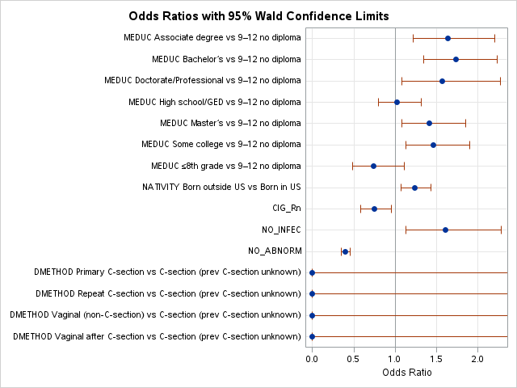

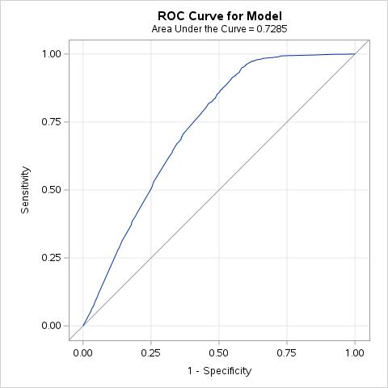

| Partition for the Hosmer and Lemeshow Test Group | Partition for the Hosmer and Lemeshow Test Total | Partition for the Hosmer and Lemeshow Test outcome_flag = 1 Observed | Partition for the Hosmer and Lemeshow Test outcome_flag = 1 Expected | Partition for the Hosmer and Lemeshow Test outcome_flag = 0 Observed | Partition for the Hosmer and Lemeshow Test outcome_flag = 0 Expected |
| --- | --- | --- | --- | --- | --- |
| 1 | 1641 | 907 | 885.38 | 734 | 755.62 |
| 2 | 1645 | 1483 | 1449.68 | 162 | 195.32 |
| 3 | 2102 | 1899 | 1923.15 | 203 | 178.85 |
| 4 | 1264 | 1178 | 1176.50 | 86 | 87.50 |
| 5 | 1777 | 1665 | 1667.06 | 112 | 109.94 |
| 6 | 1578 | 1477 | 1483.30 | 101 | 94.70 |
| 7 | 1391 | 1306 | 1314.77 | 85 | 76.23 |
| 8 | 538 | 510 | 510.16 | 28 | 27.84 |
| 9 | 2450 | 2326 | 2324.57 | 124 | 125.43 |
| 10 | 1829 | 1730 | 1746.42 | 99 | 82.58 |

| Hosmer and Lemeshow Goodness-of-Fit Test Chi-Square | Hosmer and Lemeshow Goodness-of-Fit Test DF | Hosmer and Lemeshow Goodness-of-Fit Test Pr > ChiSq |
| --- | --- | --- |
| 16.1840 | 8 | 0.0398 |

ROC Model: Triplets Model

| Model Convergence Status |
| --- |
| Convergence criterion (GCONV=1E-8) satisfied. |

| -2 Log L | = | 11028.316 |
| --- | --- | --- |

| Analysis of Maximum Likelihood Estimates Parameter | Analysis of Maximum Likelihood Estimates DF | Analysis of Maximum Likelihood Estimates Estimate | Analysis of Maximum Likelihood Estimates Standard Error | Analysis of Maximum Likelihood Estimates Wald Chi-Square | Analysis of Maximum Likelihood Estimates Pr > ChiSq | Analysis of Maximum Likelihood Estimates Standardized Estimate |
| --- | --- | --- | --- | --- | --- | --- |
| Intercept | 1 | 2.1224 | 0.0254 | 6975.7010 | <.0001 |  |

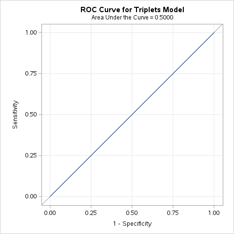

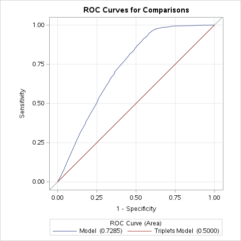

| ROC Association Statistics ROC Model | ROC Association Statistics Mann-Whitney Area | ROC Association Statistics Mann-Whitney Standard Error | ROC Association Statistics Mann-Whitney 95% Wald Confidence Limits | ROC Association Statistics Mann-Whitney 95% Wald Confidence Limits | ROC Association Statistics Somers' D | ROC Association Statistics Gamma | ROC Association Statistics Tau-a |  |  |  |
| --- | --- | --- | --- | --- | --- | --- | --- | --- | --- | --- |
| Model | 0.7285 | 0.00750 | 0.7138 | 0.7432 |  |  |  | 0.4571 | 0.4736 | 0.0873 |
| Triplets Model | 0.5000 | 0 | 0.5000 | 0.5000 | 0 | . | 0 |  |  |  |

Logistic Regression Parameter Estimates – Triplets Model

| Obs | Variable | Level of Variable | Estimate | Standard Error | Wald Chi-Square | Pr > Chi-Square | Standardized Estimate (MLE) |
| --- | --- | --- | --- | --- | --- | --- | --- |
| 1 | Intercept |  | 12.0976 | 205.8 | 0.0035 | 0.9531 | _ |
| 2 | MEDUC | Associate degree | 0.4906 | 0.1521 | 10.3972 | 0.0013 | 0.0793 |
| 3 | MEDUC | Bachelor’s | 0.5502 | 0.1296 | 18.0291 | <.0001 | 0.1377 |
| 4 | MEDUC | Doctorate/Professional | 0.4481 | 0.1890 | 5.6200 | 0.0178 | 0.0482 |
| 5 | MEDUC | High school/GED | 0.0236 | 0.1281 | 0.0339 | 0.8540 | 0.00499 |
| 6 | MEDUC | Master’s | 0.3453 | 0.1390 | 6.1728 | 0.0130 | 0.0678 |
| 7 | MEDUC | Some college | 0.3791 | 0.1337 | 8.0418 | 0.0046 | 0.0795 |
| 8 | MEDUC | ≤8th grade | -0.3080 | 0.2117 | 2.1161 | 0.1458 | -0.0235 |
| 9 | NATIVITY | Born outside US | 0.2093 | 0.0747 | 7.8533 | 0.0051 | 0.0477 |
| 10 | CIG_Rn |  | -0.2948 | 0.1273 | 5.3631 | 0.0206 | -0.0329 |
| 11 | NO_INFEC |  | 0.4735 | 0.1789 | 7.0031 | 0.0081 | 0.0350 |
| 12 | NO_ABNORM |  | -0.9231 | 0.0687 | 180.6408 | <.0001 | -0.1748 |
| 13 | DMETHOD | Primary C-section | -10.2018 | 205.8 | 0.0025 | 0.9605 | -2.3906 |
| 14 | DMETHOD | Repeat C-section | -10.2135 | 205.8 | 0.0025 | 0.9604 | -2.1317 |
| 15 | DMETHOD | Vaginal (non-C-section) | -13.0177 | 205.8 | 0.0040 | 0.9496 | -1.6988 |
| 16 | DMETHOD | Vaginal after C-section | -12.7668 | 205.8 | 0.0038 | 0.9505 | -0.4055 |
| 17 | Intercept |  | 2.1224 | 0.0254 | 6975.7010 | <.0001 | _ |

Wald Odds Ratios for Triplets

| Effect | Odds Ratio | Wald Lower 95% Confidence Limit for Adjusted Odds Ratio | Wald Upper 95% Confidence Limit for Adjusted Odds Ratio |
| --- | --- | --- | --- |
| MEDUC Associate degree vs 9–12 no diploma | 1.633 | 1.212 | 2.201 |
| MEDUC Bachelor’s vs 9–12 no diploma | 1.734 | 1.345 | 2.235 |
| MEDUC Doctorate/Professional vs 9–12 no diploma | 1.565 | 1.081 | 2.267 |
| MEDUC High school/GED vs 9–12 no diploma | 1.024 | 0.797 | 1.316 |
| MEDUC Master’s vs 9–12 no diploma | 1.412 | 1.076 | 1.854 |
| MEDUC Some college vs 9–12 no diploma | 1.461 | 1.124 | 1.898 |
| MEDUC ≤8th grade vs 9–12 no diploma | 0.735 | 0.485 | 1.113 |
| NATIVITY Born outside US vs Born in US | 1.233 | 1.065 | 1.427 |
| CIG_Rn | 0.745 | 0.580 | 0.956 |
| NO_INFEC | 1.606 | 1.131 | 2.280 |
| NO_ABNORM | 0.397 | 0.347 | 0.455 |
| DMETHOD Primary C-section vs C-section (prev C-section unknown) | <0.001 | <0.001 | >999.999 |
| DMETHOD Repeat C-section vs C-section (prev C-section unknown) | <0.001 | <0.001 | >999.999 |
| DMETHOD Vaginal (non-C-section) vs C-section (prev C-section unknown) | <0.001 | <0.001 | >999.999 |
| DMETHOD Vaginal after C-section vs C-section (prev C-section unknown) | <0.001 | <0.001 | >999.999 |

ROC Association Stats for Triplets

[output not shown]

Event Distribution – Quadruplets

The FREQ Procedure

| outcome_flag | Frequency | Percent |
| --- | --- | --- |
| 0 | 210 | 26.85 |
| 1 | 572 | 73.15 |

Event Distribution – Quadruplets

The LOGISTIC Procedure

| Model Information |  |
| --- | --- |
| Data Set | WORK.QUADRUPLETS |
| Response Variable | outcome_flag |
| Number of Response Levels | 2 |
| Model | binary logit |
| Optimization Technique | Fisher's scoring |

| Number of Observations Read | 782 |
| --- | --- |
| Number of Observations Used | 725 |

| Response Profile Ordered Value | Response Profile outcome_flag | Response Profile Total Frequency |
| --- | --- | --- |
| 1 | 0 | 166 |
| 2 | 1 | 559 |

Probability modeled is outcome_flag=1.

Note:57 observations were deleted due to missing values for the response or explanatory variables.

| Class Level Information Class | Class Level Information Value | Class Level Information Design Variables | Class Level Information Design Variables | Class Level Information Design Variables | Class Level Information Design Variables | Class Level Information Design Variables | Class Level Information Design Variables | Class Level Information Design Variables |
| --- | --- | --- | --- | --- | --- | --- | --- | --- |
| MEDUC | 9–12 no diploma | 0 | 0 | 0 | 0 | 0 | 0 | 0 |
|  | Associate degree | 1 | 0 | 0 | 0 | 0 | 0 | 0 |
|  | Bachelor’s | 0 | 1 | 0 | 0 | 0 | 0 | 0 |
|  | Doctorate/Professional | 0 | 0 | 1 | 0 | 0 | 0 | 0 |
|  | High school/GED | 0 | 0 | 0 | 1 | 0 | 0 | 0 |
|  | Master’s | 0 | 0 | 0 | 0 | 1 | 0 | 0 |
|  | Some college | 0 | 0 | 0 | 0 | 0 | 1 | 0 |
|  | ≤8th grade | 0 | 0 | 0 | 0 | 0 | 0 | 1 |
| NATIVITY | Born in US | 0 |  |  |  |  |  |  |
|  | Born outside US | 1 |  |  |  |  |  |  |
| DMETHOD | C-section (prev C-section unknown) | 0 | 0 | 0 | 0 |  |  |  |
|  | Primary C-section | 1 | 0 | 0 | 0 |  |  |  |
|  | Repeat C-section | 0 | 1 | 0 | 0 |  |  |  |
|  | Vaginal (non-C-section) | 0 | 0 | 1 | 0 |  |  |  |
|  | Vaginal after C-section | 0 | 0 | 0 | 1 |  |  |  |

| Model Convergence Status |
| --- |
| Quasi-complete separation of data points detected. |

| Model Fit Statistics Criterion | Model Fit Statistics Intercept Only | Model Fit Statistics Intercept and Covariates |
| --- | --- | --- |
| AIC | 782.134 | 598.732 |
| SC | 786.720 | 672.111 |
| -2 Log L | 780.134 | 566.732 |

| R-Square | 0.2550 | Max-rescaled R-Square | 0.3869 |
| --- | --- | --- | --- |

| Testing Global Null Hypothesis: BETA=0 Test | Testing Global Null Hypothesis: BETA=0 Chi-Square | Testing Global Null Hypothesis: BETA=0 DF | Testing Global Null Hypothesis: BETA=0 Pr > ChiSq |
| --- | --- | --- | --- |
| Likelihood Ratio | 213.4021 | 15 | <.0001 |
| Score | 225.3717 | 15 | <.0001 |
| Wald | 86.6830 | 15 | <.0001 |

| Type 3 Analysis of Effects Effect | Type 3 Analysis of Effects DF | Type 3 Analysis of Effects Wald Chi-Square | Type 3 Analysis of Effects Pr > ChiSq |
| --- | --- | --- | --- |
| MEDUC | 7 | 20.5741 | 0.0045 |
| NATIVITY | 1 | 2.5264 | 0.1120 |
| CIG_Rn | 1 | 0.0140 | 0.9058 |
| NO_INFEC | 1 | 0.0362 | 0.8490 |
| NO_ABNORM | 1 | 12.6825 | 0.0004 |
| DMETHOD | 4 | 51.6447 | <.0001 |

| Analysis of Maximum Likelihood Estimates Parameter | Analysis of Maximum Likelihood Estimates | Analysis of Maximum Likelihood Estimates DF | Analysis of Maximum Likelihood Estimates Estimate | Analysis of Maximum Likelihood Estimates Standard Error | Analysis of Maximum Likelihood Estimates Wald Chi-Square | Analysis of Maximum Likelihood Estimates Pr > ChiSq | Analysis of Maximum Likelihood Estimates Standardized Estimate |
| --- | --- | --- | --- | --- | --- | --- | --- |
| Intercept |  | 1 | -1.0335 | 213.3 | 0.0000 | 0.9961 |  |
| MEDUC | Associate degree | 1 | -0.7058 | 0.6476 | 1.1878 | 0.2758 | -0.1157 |
| MEDUC | Bachelor’s | 1 | 0.4316 | 0.6096 | 0.5014 | 0.4789 | 0.1116 |
| MEDUC | Doctorate/Professional | 1 | 1.2703 | 1.0504 | 1.4625 | 0.2265 | 0.0930 |
| MEDUC | High school/GED | 1 | 0.8407 | 0.6538 | 1.6537 | 0.1985 | 0.1800 |
| MEDUC | Master’s | 1 | -0.4323 | 0.6248 | 0.4788 | 0.4890 | -0.0859 |
| MEDUC | Some college | 1 | 0.00420 | 0.6301 | 0.0000 | 0.9947 | 0.000867 |
| MEDUC | ≤8th grade | 1 | -12.2575 | 94.7334 | 0.0167 | 0.8970 | -0.5009 |
| NATIVITY | Born outside US | 1 | 0.4627 | 0.2911 | 2.5264 | 0.1120 | 0.1115 |
| CIG_Rn |  | 1 | -0.1391 | 1.1758 | 0.0140 | 0.9058 | -0.00750 |
| NO_INFEC |  | 1 | 11.9118 | 62.5787 | 0.0362 | 0.8490 | 0.8033 |
| NO_ABNORM |  | 1 | -1.3417 | 0.3767 | 12.6825 | 0.0004 | -0.2227 |
| DMETHOD | Primary C-section | 1 | -9.2825 | 203.9 | 0.0021 | 0.9637 | -2.1698 |
| DMETHOD | Repeat C-section | 1 | -9.2859 | 203.9 | 0.0021 | 0.9637 | -1.8379 |
| DMETHOD | Vaginal (non-C-section) | 1 | -12.7614 | 203.9 | 0.0039 | 0.9501 | -1.8797 |
| DMETHOD | Vaginal after C-section | 1 | -22.0598 | 257.8 | 0.0073 | 0.9318 | -0.7813 |

| Odds Ratio Estimates and Wald Confidence Intervals Effect | Odds Ratio Estimates and Wald Confidence Intervals Unit | Odds Ratio Estimates and Wald Confidence Intervals Estimate | Odds Ratio Estimates and Wald Confidence Intervals 95% Confidence Limits | Odds Ratio Estimates and Wald Confidence Intervals 95% Confidence Limits |
| --- | --- | --- | --- | --- |
| MEDUC Associate degree vs 9–12 no diploma | 1.0000 | 0.494 | 0.139 | 1.757 |
| MEDUC Bachelor’s vs 9–12 no diploma | 1.0000 | 1.540 | 0.466 | 5.085 |
| MEDUC Doctorate/Professional vs 9–12 no diploma | 1.0000 | 3.562 | 0.455 | 27.911 |
| MEDUC High school/GED vs 9–12 no diploma | 1.0000 | 2.318 | 0.644 | 8.349 |
| MEDUC Master’s vs 9–12 no diploma | 1.0000 | 0.649 | 0.191 | 2.208 |
| MEDUC Some college vs 9–12 no diploma | 1.0000 | 1.004 | 0.292 | 3.453 |
| MEDUC ≤8th grade vs 9–12 no diploma | 1.0000 | <0.001 | <0.001 | >999.999 |
| NATIVITY Born outside US vs Born in US | 1.0000 | 1.588 | 0.898 | 2.810 |
| CIG_Rn | 1.0000 | 0.870 | 0.087 | 8.718 |
| NO_INFEC | 1.0000 | >999.999 | <0.001 | >999.999 |
| NO_ABNORM | 1.0000 | 0.261 | 0.125 | 0.547 |
| DMETHOD Primary C-section vs C-section (prev C-section unknown) | 1.0000 | <0.001 | <0.001 | >999.999 |
| DMETHOD Repeat C-section vs C-section (prev C-section unknown) | 1.0000 | <0.001 | <0.001 | >999.999 |
| DMETHOD Vaginal (non-C-section) vs C-section (prev C-section unknown) | 1.0000 | <0.001 | <0.001 | >999.999 |
| DMETHOD Vaginal after C-section vs C-section (prev C-section unknown) | 1.0000 | <0.001 | <0.001 | >999.999 |

[figure not shown]

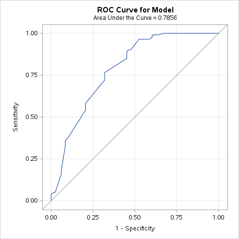

| Partition for the Hosmer and Lemeshow Test Group | Partition for the Hosmer and Lemeshow Test Total | Partition for the Hosmer and Lemeshow Test outcome_flag = 1 Observed | Partition for the Hosmer and Lemeshow Test outcome_flag = 1 Expected | Partition for the Hosmer and Lemeshow Test outcome_flag = 0 Observed | Partition for the Hosmer and Lemeshow Test outcome_flag = 0 Expected |
| --- | --- | --- | --- | --- | --- |
| 1 | 73 | 7 | 7.29 | 66 | 65.71 |
| 2 | 75 | 51 | 51.93 | 24 | 23.07 |
| 3 | 96 | 73 | 73.13 | 23 | 22.87 |
| 4 | 112 | 95 | 92.77 | 17 | 19.23 |
| 5 | 33 | 31 | 28.48 | 2 | 4.52 |
| 6 | 107 | 90 | 94.55 | 17 | 12.45 |
| 7 | 32 | 29 | 28.41 | 3 | 3.59 |
| 8 | 86 | 82 | 79.08 | 4 | 6.92 |
| 9 | 111 | 101 | 103.36 | 10 | 7.64 |

| Hosmer and Lemeshow Goodness-of-Fit Test Chi-Square | Hosmer and Lemeshow Goodness-of-Fit Test DF | Hosmer and Lemeshow Goodness-of-Fit Test Pr > ChiSq |
| --- | --- | --- |
| 6.1256 | 7 | 0.5252 |

ROC Model: Quadruplets Model

| Model Convergence Status |
| --- |
| Convergence criterion (GCONV=1E-8) satisfied. |

| -2 Log L | = | 780.134 |
| --- | --- | --- |

| Analysis of Maximum Likelihood Estimates Parameter | Analysis of Maximum Likelihood Estimates DF | Analysis of Maximum Likelihood Estimates Estimate | Analysis of Maximum Likelihood Estimates Standard Error | Analysis of Maximum Likelihood Estimates Wald Chi-Square | Analysis of Maximum Likelihood Estimates Pr > ChiSq | Analysis of Maximum Likelihood Estimates Standardized Estimate |
| --- | --- | --- | --- | --- | --- | --- |
| Intercept | 1 | 1.2142 | 0.0884 | 188.6839 | <.0001 |  |

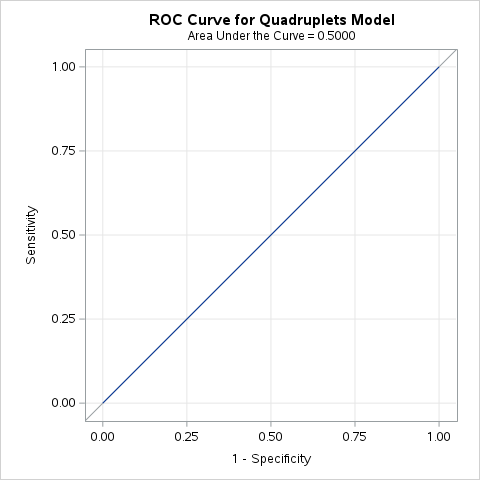

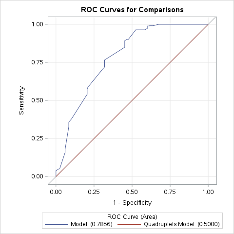

| ROC Association Statistics ROC Model | ROC Association Statistics Mann-Whitney Area | ROC Association Statistics Mann-Whitney Standard Error | ROC Association Statistics Mann-Whitney 95% Wald Confidence Limits | ROC Association Statistics Mann-Whitney 95% Wald Confidence Limits | ROC Association Statistics Somers' D | ROC Association Statistics Gamma | ROC Association Statistics Tau-a |  |  |  |
| --- | --- | --- | --- | --- | --- | --- | --- | --- | --- | --- |
| Model | 0.7856 | 0.0224 | 0.7416 | 0.8296 |  |  |  | 0.5713 | 0.6009 | 0.2020 |
| Quadruplets Model | 0.5000 | 0 | 0.5000 | 0.5000 | 0 | . | 0 |  |  |  |

Logistic Regression Parameter Estimates – Quadruplets Model

| Variable | Level of Variable | Estimate | Standard Error | Wald Chi-Square | Pr > Chi-Square | Standardized Estimate (MLE) |
| --- | --- | --- | --- | --- | --- | --- |
| Intercept |  | -1.0335 | 213.3 | 0.0000 | 0.9961 | _ |
| MEDUC | Associate degree | -0.7058 | 0.6476 | 1.1878 | 0.2758 | -0.1157 |
| MEDUC | Bachelor’s | 0.4316 | 0.6096 | 0.5014 | 0.4789 | 0.1116 |
| MEDUC | Doctorate/Professional | 1.2703 | 1.0504 | 1.4625 | 0.2265 | 0.0930 |
| MEDUC | High school/GED | 0.8407 | 0.6538 | 1.6537 | 0.1985 | 0.1800 |
| MEDUC | Master’s | -0.4323 | 0.6248 | 0.4788 | 0.4890 | -0.0859 |
| MEDUC | Some college | 0.00420 | 0.6301 | 0.0000 | 0.9947 | 0.000867 |
| MEDUC | ≤8th grade | -12.2575 | 94.7334 | 0.0167 | 0.8970 | -0.5009 |
| NATIVITY | Born outside US | 0.4627 | 0.2911 | 2.5264 | 0.1120 | 0.1115 |
| CIG_Rn |  | -0.1391 | 1.1758 | 0.0140 | 0.9058 | -0.00750 |
| NO_INFEC |  | 11.9118 | 62.5787 | 0.0362 | 0.8490 | 0.8033 |
| NO_ABNORM |  | -1.3417 | 0.3767 | 12.6825 | 0.0004 | -0.2227 |
| DMETHOD | Primary C-section | -9.2825 | 203.9 | 0.0021 | 0.9637 | -2.1698 |
| DMETHOD | Repeat C-section | -9.2859 | 203.9 | 0.0021 | 0.9637 | -1.8379 |
| DMETHOD | Vaginal (non-C-section) | -12.7614 | 203.9 | 0.0039 | 0.9501 | -1.8797 |
| DMETHOD | Vaginal after C-section | -22.0598 | 257.8 | 0.0073 | 0.9318 | -0.7813 |
| Intercept |  | 1.2142 | 0.0884 | 188.6839 | <.0001 | _ |

Wald Odds Ratios for Quadruplets

| Effect | Odds Ratio | Wald Lower 95% Confidence Limit for Adjusted Odds Ratio | Wald Upper 95% Confidence Limit for Adjusted Odds Ratio |
| --- | --- | --- | --- |
| MEDUC Associate degree vs 9–12 no diploma | 0.494 | 0.139 | 1.757 |
| MEDUC Bachelor’s vs 9–12 no diploma | 1.540 | 0.466 | 5.085 |
| MEDUC Doctorate/Professional vs 9–12 no diploma | 3.562 | 0.455 | 27.911 |
| MEDUC High school/GED vs 9–12 no diploma | 2.318 | 0.644 | 8.349 |
| MEDUC Master’s vs 9–12 no diploma | 0.649 | 0.191 | 2.208 |
| MEDUC Some college vs 9–12 no diploma | 1.004 | 0.292 | 3.453 |
| MEDUC ≤8th grade vs 9–12 no diploma | <0.001 | <0.001 | >999.999 |
| NATIVITY Born outside US vs Born in US | 1.588 | 0.898 | 2.810 |
| CIG_Rn | 0.870 | 0.087 | 8.718 |
| NO_INFEC | >999.999 | <0.001 | >999.999 |
| NO_ABNORM | 0.261 | 0.125 | 0.547 |
| DMETHOD Primary C-section vs C-section (prev C-section unknown) | <0.001 | <0.001 | >999.999 |
| DMETHOD Repeat C-section vs C-section (prev C-section unknown) | <0.001 | <0.001 | >999.999 |
| DMETHOD Vaginal (non-C-section) vs C-section (prev C-section unknown) | <0.001 | <0.001 | >999.999 |
| DMETHOD Vaginal after C-section vs C-section (prev C-section unknown) | <0.001 | <0.001 | >999.999 |

ROC Association Stats for Quadruplets

[output not shown]

Frequency and row proportion of MEDUC by PLURAL

| Plurality | MEDUC | Frequency | Proportion (row %) |
| --- | --- | --- | --- |
| Twin | ≤8th grade | 13101 | 2.10% |
| Twin | 9–12 no diploma | 45332 | 7.27% |
| Twin | High school/GED | 139673 | 22.39% |
| Twin | Some college | 120644 | 19.34% |
| Twin | Associate degree | 54347 | 8.71% |
| Twin | Bachelor’s | 143023 | 22.92% |
| Twin | Master’s | 74057 | 11.87% |
| Twin | Doctorate/Professional | 21829 | 3.50% |
| Twin | Unknown | 11947 | 1.91% |
| Triplet | ≤8th grade | 334 | 1.94% |
| Triplet | 9–12 no diploma | 880 | 5.12% |
| Triplet | High school/GED | 3064 | 17.81% |
| Triplet | Some college | 2948 | 17.14% |
| Triplet | Associate degree | 1596 | 9.28% |
| Triplet | Bachelor’s | 4859 | 28.25% |
| Triplet | Master’s | 2487 | 14.46% |
| Triplet | Doctorate/Professional | 658 | 3.83% |
| Triplet | Unknown | 373 | 2.17% |
| Quadruplet | ≤8th grade | 5 | 0.64% |
| Quadruplet | 9–12 no diploma | 34 | 4.35% |
| Quadruplet | High school/GED | 139 | 17.77% |
| Quadruplet | Some college | 129 | 16.50% |
| Quadruplet | Associate degree | 75 | 9.59% |
| Quadruplet | Bachelor’s | 249 | 31.84% |
| Quadruplet | Master’s | 117 | 14.96% |
| Quadruplet | Doctorate/Professional | 13 | 1.66% |
| Quadruplet | Unknown | 21 | 2.69% |

Frequency and row proportion of NATIVITY by PLURAL

| Plurality | NATIVITY | Frequency | Proportion (row %) |
| --- | --- | --- | --- |
| Twin | Born in US | 501148 | 80.32% |
| Twin | Born outside US | 120959 | 19.39% |
| Twin | Unknown | 1846 | 0.30% |
| Triplet | Born in US | 13358 | 77.67% |
| Triplet | Born outside US | 3791 | 22.04% |
| Triplet | Unknown | 50 | 0.29% |
| Quadruplet | Born in US | 585 | 74.81% |
| Quadruplet | Born outside US | 197 | 25.19% |

Frequency and row proportion of CIG_R by PLURAL

| Plurality | CIG_R | Frequency | Proportion (row %) |
| --- | --- | --- | --- |
| Twin | No | 582082 | 93.29% |
| Twin | Unknown | 3480 | 0.56% |
| Twin | Yes | 38391 | 6.15% |
| Triplet | No | 16377 | 95.22% |
| Triplet | Unknown | 81 | 0.47% |
| Triplet | Yes | 741 | 4.31% |
| Quadruplet | No | 763 | 97.57% |
| Quadruplet | Unknown | 12 | 1.53% |
| Quadruplet | Yes | 7 | 0.90% |

Frequency and row proportion of NO_INFEC by PLURAL

| Plurality | NO_INFEC | Frequency | Proportion (row %) |
| --- | --- | --- | --- |
| Twin | . | 7691 | 1.23% |
| Twin | FALSE | 15259 | 2.45% |
| Twin | No infection TRUE | 598741 | 95.96% |
| Twin | Not reported | 2262 | 0.36% |
| Triplet | . | 472 | 2.74% |
| Triplet | FALSE | 311 | 1.81% |
| Triplet | No infection TRUE | 16329 | 94.94% |
| Triplet | Not reported | 87 | 0.51% |
| Quadruplet | . | 37 | 4.73% |
| Quadruplet | FALSE | 11 | 1.41% |
| Quadruplet | No infection TRUE | 733 | 93.73% |
| Quadruplet | Not reported | 1 | 0.13% |

Frequency and row proportion of NO_ABNORM by PLURAL

| Plurality | NO_ABNORM | Frequency | Proportion (row %) |
| --- | --- | --- | --- |
| Twin | . | 7691 | 1.23% |
| Twin | False | 257818 | 41.32% |
| Twin | True | 357957 | 57.37% |
| Twin | Not reported | 487 | 0.08% |
| Triplet | . | 472 | 2.74% |
| Triplet | False | 14423 | 83.86% |
| Triplet | True | 2291 | 13.32% |
| Triplet | Not reported | 13 | 0.08% |
| Quadruplet | . | 37 | 4.73% |
| Quadruplet | False | 668 | 85.42% |
| Quadruplet | True | 77 | 9.85% |

Frequency and row proportion of DMETHOD by PLURAL

| Plurality | DMETHOD | Frequency | Proportion (row %) |
| --- | --- | --- | --- |
| Twin | Vaginal (non-C-section) | 165853 | 26.58% |
| Twin | Vaginal after C-section | 5338 | 0.86% |
| Twin | Primary C-section | 348083 | 55.79% |
| Twin | Repeat C-section | 103503 | 16.59% |
| Twin | Vaginal (prev C-section unknown) | 378 | 0.06% |
| Twin | C-section (prev C-section unknown) | 287 | 0.05% |
| Twin | Unknown | 511 | 0.08% |
| Triplet | Vaginal (non-C-section) | 1274 | 7.41% |
| Triplet | Vaginal after C-section | 76 | 0.44% |
| Triplet | Primary C-section | 12870 | 74.83% |
| Triplet | Repeat C-section | 2944 | 17.12% |
| Triplet | Vaginal (prev C-section unknown) | 6 | 0.03% |
| Triplet | C-section (prev C-section unknown) | 11 | 0.06% |
| Triplet | Unknown | 18 | 0.10% |
| Quadruplet | Vaginal (non-C-section) | 74 | 9.46% |
| Quadruplet | Vaginal after C-section | 5 | 0.64% |
| Quadruplet | Primary C-section | 579 | 74.04% |
| Quadruplet | Repeat C-section | 116 | 14.83% |
| Quadruplet | C-section (prev C-section unknown) | 1 | 0.13% |
| Quadruplet | Unknown | 7 | 0.90% |